# Assignment: BA model and scale-free networks

## 1. Implement BA algorithm

For this assignment you will be implementing the BA algorithm from the reading (see [Barabasi Ch 5.3](http://barabasi.com/networksciencebook/)). Create a function that takes `n` the number of nodes for the graph, and `m0` the initial number of nodes, as arguments and returns a networkx graph with a scale-free degree distribution.

The first step is figuring out how to do "preferential attachment" based on the degree of existing nodes. A brute-force way to do this is creating a huge list with duplicated items. Say, node 1's degree is 6, node 2's degree is 3, and node 3's degree is 2. (This is not a 'graphical' sequence. But for the sake of simplicity let's just assume that.) Then, we can create the following list to *preferentially sample* nodes from the network.

```python
alist = [1,1,1,1,1,1,2,2,2,3,3]
```

1 is repeated 6 times, 2 is repeated 3 times, and so on. Now if we randomly sample from this list, we will be three times more like to sample node 1 than node 3!

```python
import random

random.sample(alist, 1)
```

```
[1]
```

So, if you can maintain this list for your network, you can implement preferential attachment. Simply update this list whenever you add an edge!

A more space-efficient way is using `numpy`'s sampling method. If you run the following cell, the documentation for the [`np.random.choice`](http://docs.scipy.org/doc/numpy/reference/generated/numpy.random.choice.html) function will appear.

```python
import numpy as np

np.random.choice?
```

It accepts `p` parameter and you can specifies the probability of each item in the list! So instead of creating

```python
alist = [1,1,1,1,1,1,2,2,2,3,3]
```

You can do

```python
nodes = [1,2,3]
degrees = [6,3,2]
sum_degrees = sum(degrees)
node_probs = [degree*1.0/sum_degrees for node, degree in zip(nodes,degrees)]
node_probs
```

```
[0.5454545454545454, 0.2727272727272727, 0.18181818181818182]
```

```python
np.random.choice(nodes, p=node_probs)
```

```
1
```

or sample two nodes from the list.

```python
np.random.choice(nodes, 2, replace=False, p=node_probs)
```

```
array([1, 3])
```

Ok, now the sampling can be done. How about the initial graph with `m0` nodes? `networkx` has a convenient function for that: https://networkx.org/documentation/stable/reference/generated/networkx.generators.classic.complete_graph.html

Can you create a complete graph with 5 nodes and then check the edges to make sure you have the right graph?

```python
# Implement ---
import networkx as nx
G = nx.complete_graph(5)
G.edges()
```

```
EdgeView([(0, 1), (0, 2), (0, 3), (0, 4), (1, 2), (1, 3), (1, 4), (2, 3), (2, 4), (3, 4)])
```

Now you're ready to implement the BA algorithm! Create a fully-connected network with `m0` nodes. Then in each step, sample `m` nodes from the existing node pool. Add a new node and connect it to the chosen `m` nodes.

```python
def barabasi_albert_graph(n, m0, m=1):
    """Create a BA network with n nodes, where each new node connects to
    m existing nodes according to the preferential attachment rule. The initial
    network is a clique (fully-connected network) with m0 nodes.
    """
    # Initial network of m0 nodes (a complete graph)
    G = nx.complete_graph(m0)
    d = nx.degree(G)
    for i in range(m, n+1):
      G.add_node(i)
      probDict = {}
      probs = []
      for nodes in G.nodes():
        prob = G.degree(nodes)/sum([x[1] for x in d])
        probDict[nodes] = prob
        probs.append(prob)
      selection_random = np.random.choice(G.nodes(), m0, replace=False, p=probs)
      for j in range(0, len(selection_random)):
        G.add_edge(i,selection_random.item(j))

    # ---
    return G
```

## 2. BA graph analysis

Test your algorithm by creating a graph with `N = 1200` and `m0 = 7`. Calculate (and print) the average shortest path length of the graph:

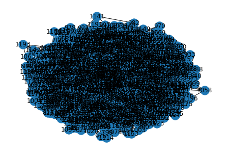

```python
import matplotlib.pyplot as plt
# Implement ---
N=1200
m0=7
G = barabasi_albert_graph(N, m0, m=1)

plt.figure()
nx.draw(G, with_labels=True)
plt.show()
```

Calculate (and print) the average clustering coefficient of the graph:

```python
# Implement ---
NumbOfEdges=G.number_of_edges()
print("The Number of edges",NumbOfEdges)
AvgShortPath=nx.average_shortest_path_length(G)
print("The average shortest path",AvgShortPath)
AvgClusCoeff=nx.average_clustering(G)
print("The average clustering coefficient",AvgClusCoeff)
```

```
The Number of edges 8385
The average shortest path 2.7721107410491257
The average clustering coefficient 0.048477841804797764
```

The [cumulative distribution function (CDF) and complementary cumulative distribution function (CCDF)](https://en.wikipedia.org/wiki/Cumulative_distribution_function) are among the most direct ways to identify a power-law-like distribution. Plot the **CCDF** of the graph's degree distribution.

First, **CDF** for a discrete distribution is defined as the following:

$$ F_X(x) = P(X \le x) = \sum_{x' \le x} P(x') $$

CCDF is it's reverse and is defined as following:

$$\bar F_X(x) = P(X > x) = \sum_{x' > x} P(x') = 1 - F_X(x).$$

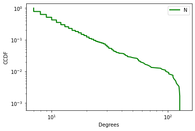

```python
import numpy as np
import networkx as nx
import matplotlib.pyplot as plt

degrees = [val for (node, val) in G.degree()]
sortDegrees = np.sort(degrees) #get the degree of all nodes in the graph and sort them
y = 1 - np.arange(0., N+1)/N # probability in terms of a rank order
plt.loglog(sortDegrees,y,label='N',color='green', linestyle='-',linewidth=2) # plot the CCDF. This makes the tail easy to visualize
plt.xlabel('Degrees')
plt.ylabel('CCDF')
plt.legend(loc=0)
```

## 3. BA and ER comparison

Now let's compare the scale-free and random graphs. Create a random graph with the same number of nodes and about the same number of edges, then calculate the average shortest path length of that graph:

Note: Please extract the largest connected component (using networkx) and calculate the average path length of that component

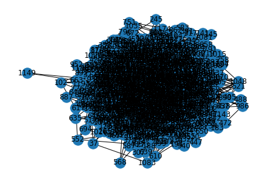

```python
# Implement ---
def averageDegree(G):
  degrees = [val for (node, val) in G.degree()]
  return sum(degrees)/len(G.nodes())

def probabilityForEdge(N, k):
    return k/(N-1)

k = averageDegree(G)
p = probabilityForEdge(N, k)
myrandomgraph = nx.erdos_renyi_graph(N, p)

plt.figure()
nx.draw(myrandomgraph, with_labels=True)
plt.show()
```

```python
#largest connected component
largest_cc = max(nx.connected_components(myrandomgraph), key=len)

listoflength=[]
for C in (myrandomgraph.subgraph(c).copy() for c in sorted(nx.connected_components(myrandomgraph), key=len, reverse=True)):
    listoflength.append(nx.average_shortest_path_length(C))

print(listoflength)
print(listoflength[0])
```

```
[2.9528051153739225]
2.9528051153739225
```

Calculate (and print) the average clustering coefficient of the graph:

```python
# Implement ---
print("The average clustering coefficient is {0:.3f}".format(nx.average_clustering(myrandomgraph)))
```

```
The average clustering coefficient is 0.012
```

Now plot the CCDF of the degree distribution of the random graph:

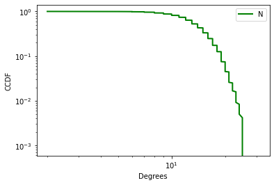

```python
# Implement ---

Rdegrees = [val for (node, val) in myrandomgraph.degree()]
RsortDegrees = np.sort(Rdegrees) #get the degree of all nodes in the graph and sort them
Ry = 1 - np.arange(1., N+1)/N # probability in terms of a rank order
plt.loglog(RsortDegrees,Ry,label='N',color='green', linestyle='-',linewidth=2) # plot the CCDF. This makes the tail easy to visualize
plt.xlabel('Degrees')
plt.ylabel('CCDF')
plt.legend(loc=0)
```

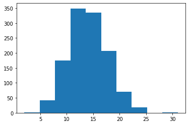

```python
(v, e, p) = plt.hist(Rdegrees)
```

How do the average shortest path lengths, average clustering coefficients, and degree distributions between the graphs compare?

The table below provides a summary of the average shortest path lengths and average clustering coefficients.

| Graph Type | Average Shortest Path Length | Average Clustering Coefficient |
| --- | --- | --- |
| Barabasi-Albert | 2.772 | 0.0485 |
| Erdos-Renyi | 2.953 | 0.012 |

The two graph types have comparable *Average Shortest Path Length*. The Barabasi-Albert model has an *Average Clustering Coefficient* that is approximately 4x the *Average Clustering Coefficient* of Erdos-Renyi model. This means that there is more clustering in the Barabasi-Albert model, which would be obvious due to the presence of hubs.

The most remarkable difference between the two graph types is the degree distribution, which is best understood by observing the CCDF graphs plotted above. The Barabasi-Albert model shows a Power-Law distribution: the majority of nodes have a degree under 30 and almost all have their degrees under 60 but the distribution has a *fat tail* which suggests that there are outliers with degree as large as 130-140 or a little bit higher. Looking at both the CCDF plot and the histogram, the Erdos-Renyi network, in contrast, shows a degree distribution representing a normal distribution - nodes have a degree between 5 to 25 approximately. Most of the the nodes have a degree between 10 and 20 and the maximum is around 12 or 13.

## 4. Preferential attachment without using the degree

As you know from the discussion and videos, it is possible to achieve the linear preferential attachment without calculating the degree by using the friendship paradox. Implement this version and see whether you can get a power-law degree distribution.

```python
# Implement ---

def ba_without_using_degree(n,m0,m=1):
  G = nx.complete_graph(m0)

  for i in range(m0+1, n+1):
    G.add_node(i)
    edge_view = G.edges()
    edge_view = np.array(edge_view)
    index = np.random.choice(len(edge_view),1, replace=False)
    tup=edge_view[index]
    tup_lst=tup[0]
    selection_node=np.random.choice(tup_lst,1,replace=False)
    G.add_edge(i,selection_node.item(0))
  return G
```

```python
N=1200
m0=7
G=ba_without_using_degree(N,m0,m=1)
```

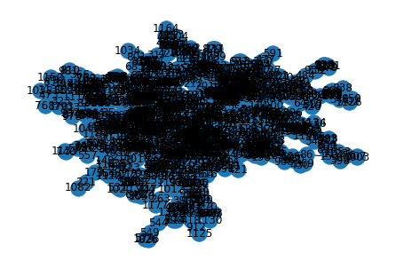

```python
plt.figure()
nx.draw(G,with_labels=True)
plt.show()
```

```python
# Implement ---
NumbOfEdges=G.number_of_edges()
print("The Number of edges",NumbOfEdges)
AvgShortPath=nx.average_shortest_path_length(G)
print("The average shortest path",AvgShortPath)
AvgClusCoeff=nx.average_clustering(G)
print("The average clustering coefficient",AvgClusCoeff)
```

```
The Number of edges 1214
The average shortest path 5.514952738393105
The average clustering coefficient 0.0001187774745346151
```

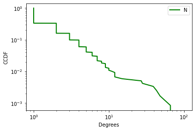

```python
degrees = [val for (node, val) in G.degree()]
sortDegrees = np.sort(degrees) #get the degree of all nodes in the graph and sort them
y = 1 - np.arange(1., N+1)/N # probability in terms of a rank order
plt.loglog(sortDegrees,y,label='N',color='green', linestyle='-',linewidth=2) # plot the CCDF. This makes the tail easy to visualize
plt.xlabel('Degrees')
plt.ylabel('CCDF')
plt.legend(loc=0)
```

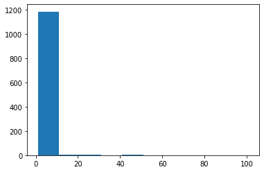

```python
(v, e, p) = plt.hist(degrees)
```

This model also shows a Power-Law distribution (not as clearly as the previous one though) : the majority of nodes have a degree under 10 and almost all have their degrees under 15-20 but the distribution has a fat tail which suggests that there are outliers with degree as large as 60-90 or a little bit higher.